# Tropical forest tree mortality, recruitment and turnover rates: calculation, interpretation and comparison when census intervals vary - LEWIS - 2004 - Journal of Ecology - Wiley Online Library

[Journal of Ecology](https://besjournals.onlinelibrary.wiley.com/journal/13652745)

[Volume 92, Issue 6](https://besjournals.onlinelibrary.wiley.com/toc/13652745/2004/92/6) p. 929-944

Free Access

# Tropical forest tree mortality, recruitment and turnover rates: calculation, interpretation and comparison when census intervals vary

[SIMON L. LEWIS](https://besjournals.onlinelibrary.wiley.com/action/doSearch?ContribAuthorRaw=LEWIS%2C+SIMON+L),

Simon L. Lewis (tel. +44 113 343 3361; fax +44 113 343 3308; e-mail ).

[OLIVER L. PHILLIPS](https://besjournals.onlinelibrary.wiley.com/action/doSearch?ContribAuthorRaw=PHILLIPS%2C+OLIVER+L),

[DOUGLAS SHEIL](https://besjournals.onlinelibrary.wiley.com/action/doSearch?ContribAuthorRaw=SHEIL%2C+DOUGLAS),

[BARBARA VINCETI](https://besjournals.onlinelibrary.wiley.com/action/doSearch?ContribAuthorRaw=VINCETI%2C+BARBARA),

[TIMOTHY R. BAKER](https://besjournals.onlinelibrary.wiley.com/action/doSearch?ContribAuthorRaw=BAKER%2C+TIMOTHY+R),

[SANDRA BROWN](https://besjournals.onlinelibrary.wiley.com/action/doSearch?ContribAuthorRaw=BROWN%2C+SANDRA),

[ANDREW W. GRAHAM](https://besjournals.onlinelibrary.wiley.com/action/doSearch?ContribAuthorRaw=GRAHAM%2C+ANDREW+W),

[NIRO HIGUCHI](https://besjournals.onlinelibrary.wiley.com/action/doSearch?ContribAuthorRaw=HIGUCHI%2C+NIRO),

[DAVID W. HILBERT](https://besjournals.onlinelibrary.wiley.com/action/doSearch?ContribAuthorRaw=HILBERT%2C+DAVID+W),

… See all authors

First published: 16 September 2004

https://doi.org/10.1111/j.0022-0477.2004.00923.x

Citations: 86

## Summary

- 1

  Mathematical proofs show that rate estimates, for example of mortality and recruitment, will decrease with increasing census interval when obtained from censuses of non-homogeneous populations. This census interval effect could be confounding or perhaps even driving conclusions from comparative studies involving such rate estimates.
- 2

  We quantify this artefact for tropical forest trees, develop correction methods and re-assess some previously published conclusions about forest dynamics.
- 3

  Mortality rates of > 50 species at each of seven sites in Africa, Latin America, Asia and Australia were used as subpopulations to simulate stand-level mortality rates in a heterogeneous population when census intervals varied: all sites showed decreasing stand mortality rates with increasing census interval length.
- 4

  Stand-level mortality rates from 14 multicensus long-term forest plots from Africa, Latin America, Asia and Australia also showed that, on average, mortality rates decreased with increasing census interval length.
- 5

  Mortality, recruitment or turnover rates with differing census interval lengths can be compared using the mean rate of decline from the 14 long-term plots to standardize estimates to a common census length using λ<sub>*corr*</sub>= λ × *t*<sup>0.08</sup>, where λ is the rate and *t* is time between censuses in years. This simple general correction should reduce the bias associated with census interval variation, where it is unavoidable.
- 6

  Re-analysis of published results shows that the pan-tropical increase in stem turnover rates over the late 20th century cannot be attributed to combining data with differing census intervals. In addition, after correction, Old World tropical forests do not have significantly lower turnover rates than New World sites, as previously reported. Our pan-tropical best estimate adjusted stem turnover rate is 1.81 ± 0.16% a<sup>−1</sup> (mean ± 95% CI, *n* = 65).
- 7

  As differing census intervals affect comparisons of mortality, recruitment and turnover rates, and can lead to erroneous conclusions, standardized field methods, the calculation of local correction factors at sites where adequate data are available, or the use of our general standardizing formula to take account of sample intervals, are to be recommended.

## Introduction

Marking, counting and measuring individuals and periodically re-counting these individuals to infer population changes is common practice for ecological studies (Begon *et al*. 1996; Krebs 1999). For studies of tropical trees this has mostly taken the form of census-based permanent plot data: delineating an area, and permanently and uniquely marking each tree stem within that area that exceeds a given lower-size threshold, often ≥ 10 cm d.b.h. (diameter at breast height, 1.3 m, or above buttresses or other bole deformities). The plot is revisited periodically to note deaths and add the trees that reach the lower size limit, and these data are then used to calculate mortality and recruitment estimates (Sheil *et al*. 1995). Almost everything we know about tropical forest dynamics derives from this method (e.g. Connell *et al*. 1984; Swaine *et al*. 1987a; Carey *et al*. 1994; Phillips & Gentry 1994; Condit *et al*. 1999; Sheil *et al*. 2000; Vásquez & Phillips 2000; Lewis *et al*. 2004a; Phillips *et al*. 2004).

Mortality and recruitment estimates are fundamental descriptors of tropical forest tree populations. Comparisons both between and among studies are important if we are to further understand tropical forest dynamics, both to make generalizations about patterns in time and space, and to infer their underlying causes (Swaine *et al*. 1987b; Hartshorn 1990; Phillips & Gentry 1994; Phillips *et al*. 1994; Phillips 1996; Lewis *et al*. 2004a; Phillips *et al*. 2004). However, these recruitment and mortality rate estimates are affected by a potentially serious artefact that may influence any conclusion based on permanent sample plots: these rate estimates are not independent of the time interval between censuses (Sheil & May 1996). Thus, conclusions based on comparing rates with differing census intervals are open to debate (for example see Phillips & Gentry 1994; responses by Phillips 1995; Sheil 1995; Phillips *et al*. 2004).

Mortality rate estimates are often based on models that assume a population is homogenous, with each member having an equal and constant probability of dying (Sheil *et al*. 1995). Sheil and May (1996) show theoretically that when a population is made up of subpopulations with differing mortality rates, the population mortality rate, on average, will decrease with increasing time between censuses. This is because higher-mortality stems die faster, leaving increasing proportions of the original cohort represented by lower-mortality stems. Over time the lower-mortality stems dominate, leading to lower estimates of population mortality rates as the census interval increases.

It is unknown whether the theoretically demonstrated decline in mortality rate with increasing census interval is a serious problem or essentially trivial over the time-scales on which ecologists measure forest dynamics. Certainly, tropical forest stands are not homogeneous with respect to the mortality, recruitment or turnover of their component subpopulations. For example, individual species’ mortality rates in three different forest stands each appear to vary by over an order of magnitude (Vanclay 1991; Favrichon 1994; Condit *et al*. 1995). Further within-stand heterogeneity may be generated if mortality rates change with stem size, as has been shown for stems ≥ 10 cm d.b.h. in several localities (Mervart 1972; Hartshorn 1990; Hubbell & Foster 1990; Vanclay 1991; Clark & Clark 1992). Additionally, heterogeneity may arise from species-level mortality rates varying according to local variation in the physical environment. Thus we expect some impact of census interval length on mortality rate estimates, but neither *a priori* predictions of the magnitude or form of declines (linear, exponential, etc.), nor initial estimates of the declines in forest stands, are known.

Accurate mortality rate estimation presents several other problems, notably the large sample sizes and long time-periods required, due to intrinsically low mortality rates and the large stochastic component of tree mortality in tropical forests. For example, in a study of 10 ha of forest in Ecuador, 20% of tree deaths > 10 cm d.b.h. were due to other trees knocking them over (Gale & Barfod 1999). Furthermore, very occasional deaths of very large trees accentuate this stochastic element by dramatically altering forest structure and hence local competition and recruitment (Sheil *et al*. 2000). A stand of 1 ha with *c*. 600 trees ≥ 10 cm d.b.h. and a mortality rate of *c*. 1.5% a<sup>−1</sup> translates to *c*. 9 trees dying ha<sup>−1</sup> a<sup>−1</sup>, hence stochastic effects altering this by only a few trees can have large effects on average mortality rates. Thus long-term and/or large-scale studies are required.

Studies of tropical tree dynamics often consider mortality but not recruitment (Swaine *et al*. 1987b; Hartshorn 1990; Vanclay 1991; Condit *et al*. 1995; Lieberman *et al*. 1996); however, many studies report both (Carey *et al*. 1994; Favrichon 1994; Phillips & Gentry 1994; Phillips 1996; Condit *et al*. 1999; Sheil *et al*. 2000). Sheil and May (1996) show that the same effect of census interval applies to recruitment rates: a decline with increasing census interval. Of course, if recruitment rate estimates chosen are calculated as the number of recruited stems needed to maintain a population in equilibrium, as is commonly the case, then, by definition, declines with increasing census length are predicted to match those for mortality. Stem turnover (*sensu*Phillips & Gentry 1994), the mean of the mortality and recruitment rates of a forest stand, would also, by definition, show the same decline with increasing census interval.

As more studies on forest dynamics are completed the scope for comparative studies and syntheses of tropical forest ecology increases, so there is an urgent need to understand and quantify the potential census-interval artefact. For example, one study of 65 sites from across the tropics showed that turnover rates have been increasing over the late 20th century, possibly as a result of increased productivity (Phillips & Gentry 1994; see Phillips 1996). However, the study included sites with a wide range of census intervals (2–38 years), and the central finding has hence been controversial (Phillips 1995; Sheil 1995; Sheil & May 1996; Condit 1997; Phillips & Sheil 1997; Phillips *et al*. 2004).

We take two approaches to assess if the census interval effect on tropical forest tree mortality, recruitment and turnover rates is a serious problem. First, we use species-level mortality rates from seven sites from Latin America, Africa, Asia and Australia, using each species as a subpopulation to calculate the expected mortality rate for each stand for census intervals from 1 up to 50 years. This gives a first estimate of the magnitude of the artefact, and a clue as to the shape of the relationship between mortality rates and census interval length. Secondly, we use 14 long-term multicensus plots from Latin America, Africa, Asia and Australia to test for a decline in mortality over time in permanent sample plot data. This gives a second estimate of the decline and its form, but will be more variable as stochastic effects and changes in mortality over time are included in the long-term data. Finally, we re-analyse Phillips's (1996) data set of 65 sites to test his conclusions about changes in forest dynamics over time and regional differences in dynamics, taking into account the differing census intervals used in each of the 65 sites.

## Methods

### simulations with large-scale data sets

where *n*<sub>0</sub> and *n<sub>t</sub>* are the number of stems in the original population, and the number of stems surviving to time *t*, respectively. The time between the two stem censuses is *t*.

For tropical forest sites where we know the original population of stems and the mortality rate for many species (the subpopulations) we can input these into the above equation and vary *t* to simulate the impact of varying the census interval on stand-level mortality rates when the stand is made up of many known subpopulations.

Table 1. Details of the large-scale data sets used for simulating declines in mortality rates with increasing census intervals using heterogeneous tree populations

| Name | Country | Data source | Latitude, longitude | Altitude (m) | Rainfall (mm) | Size (ha) | Year start | Year end | All stems No. species | All stems No. stems<sup>1</sup> | All stems No. dying | All stems Interval | Mortality rate<sup>2</sup> |
| --- | --- | --- | --- | --- | --- | --- | --- | --- | --- | --- | --- | --- | --- |
| BCI | Panama | Condit *et al*. (1995) | 9.1 N, 79.5 W | 100 | 2500 | 50.00 | 1985 | 1990 | 220 | 20 720 | 2064 | 5.3 | 1.98 ± 0.09 |
| Paracou | French Guiana | Favrichon (1994) | 5.2 N, 52.5 W | 10 | 3200 | 18.75 | 1984 | 1992 | 200 | 11 719 | 901<sup>8</sup> | 8.0 | 1.00 ± 0.07 |
| Manaus<sup>3</sup> | Brazil | Unpublished data | 2.3 S, 60.0 W | 100 | 2200 | 23.00 | 1990 | 1999 | 711<sup>9</sup> | 13 993 | 1164 | 7.9 | 1.10 ± 0.06 |
| SE Peru<sup>4</sup> | Peru | Unpublished data | *c*. 12 S, *c*. 70 W | 300 | 2200 | 21.21 | 1990 | 1998 | 711<sup>9</sup> | 10 744 | 1375 | 6.8 | 2.02 ± 0.11 |
| Dja<sup>5</sup> | Cameroon | Unpublished data | *c*. 3 N, *c*. 12 W | 600 | 1600 | 9.50 | 1993 | 1997 | 226<sup>9</sup> | 4 252 | 198 | 4.5 | 1.06 ± 0.15 |
| Pasoh | Malaysia | Unpublished data | 2.35 N, 102.19 E | 90 | 2000 | 50 | 1987 | 1995 | 678 | 26 554 | 3096 | 8.4 | 1.47 ± 0.05 |
| Queensland<sup>6</sup> | Australia | Vanclay (1991) | *c*. 15 S, *c*. 145 E | 10–1500 | 1200–3500 | Unknown<sup>6</sup> | 1950<sup>6</sup> | 1990<sup>6</sup> | 239 | 70 781 | 2963 | 5.0 | 0.86 ± 0.03 |

| Name | Only stems with ≥ 20 stems per species No. species | Only stems with ≥ 20 stems per species No. stems<sup>1</sup> | Only stems with ≥ 20 stems per species No. dying | Only stems with ≥ 20 stems per species Interval | Only stems with ≥ 20 stems per species Mortality rate<sup>2</sup> |
| --- | --- | --- | --- | --- | --- |
| BCI | 128<sup>7</sup> | 20 071 | 1979 | 5.3 | 1.95 ± 0.09 |
| Paracou | 101 | 10 378 | 709<sup>8</sup> | 8.0 | 0.88 ± 0.07 |
| Manaus<sup>3</sup> | 116 | 6 227 | 473 | 7.9 | 1.00 ± 0.09 |
| SE Peru<sup>4</sup> | 91 | 6 938 | 772 | 6.8 | 1.73 ± 0.12 |
| Dja<sup>5</sup> | 58 | 3 129 | 122 | 4.5 | 0.89 ± 0.16 |
| Pasoh | 289 | 23 881 | 2716 | 8.4 | 1.43 ± 0.05 |
| Queensland<sup>6</sup> | 99 | 59 078 | 2437 | 5.0 | 0.84 ± 0.03 |

- <sup>1</sup> ≥ 10 cm diameter at breast height (1.3 m or above deformities).
- <sup>2</sup> % a<sup>−1</sup> ± 95% CI.
- <sup>3</sup> Plot numbers: Bionte group 1, 2, 4 (1 ha each); BDFFP group 1201 (3 ha), 1301 (6 ha), 3402 (9 ha), 2303 (2 ha).
- <sup>4</sup> Plot numbers: Tambopata group 0, 1, 3, 6 (1 ha each), and 4 (0.96 ha); Cuzco Amazónico group 1E, 1 U, 2E, 2 U (1 ha each); Manu group, Otorongo, Salvador, Ravine, Terrace, Trail 3 (2 ha each), Trail 12 (2.25 ha).
- <sup>5</sup> Trees 10–70 cm d.b.h. only.
- 6 Variable number of plots of varying sizes. Earliest and latest dates of censuses given.
- <sup>7</sup> 129 subpopulations used as two subspecies of *Swartzia simplex* used.
- 8 Estimated from known initial number tree, mortality rate and census interval.
- 9 Includes only identified species, not morphospecies.

The seven areas used were, with references about site conditions in parentheses: (i) Barro Colorado Island, Panama (BCI), a single 50-ha plot on an island created by the completion of the Panama Canal (Condit *et al*. 1995); (ii) Paracou, French Guiana, 3 × 6.25 ha plots in an area of continuous forest in the Guyanan shield (Favrichon 1994); (iii) north Manaus, seven plots, 1–9 ha each, from a 1000 km<sup>2</sup> area in central Amazonia, Brazil (Laurance *et al*. 1998); (iv) south-east Peru, 15 plots, 0.96–2.25 ha, in the Manu and Tambopata National parks (Gentry & Terborgh 1990; Phillips *et al*. 1994); (v) Dja Faunal Reserve, four plots, 2–2.5 ha, in south-east Cameroon (Sonké 1998); (vi) Pasoh, a single 50-ha plot in the centre of the Malay Peninsula, Malaysia (Kochummen *et al*. 1990; Condit *et al*. 1999); (vii) North Queensland, an unknown number of plots 0.04–0.5 ha from across North Queensland, Australia (Vanclay 1991). Note that some of the North Queensland plots have been logged in the past or undergone silvicultural treatments, but the censuses used to generate the mortality rates did not span any logging or silvicultural activity (Vanclay 1991). Further details of each site are given in Table 1.

The sites are geographically widespread, and span the range of rainfall regimes that tropical forests occupy, from aseasonal Pasoh (Kochummen *et al*. 1990) to the Dja Faunal Reserve site with a long dry season and low annual rainfall (Sonké 1998; see Table 1). The sites occur on a range of soil types from the poor oxisols of central Amazonia (Laurance *et al*. 1999; Lewis & Tanner 2000) to the more fertile ultisols and inceptisols of the south-east Peru plots (Phillips *et al*. 1994; Pitman *et al*. 2001). The sites span a range of stand-level mortality rates from less than 1% a<sup>−1</sup> to greater than 2% a<sup>−1</sup> (Table 1). The environmental and dynamic variation encompassed by these sites indicates that the results from these sites will be broadly applicable to tropical forests generally.

We chose 50 years as the limit of the simulation as few studies consider intervals longer than this. While Sheil and May (1996) consider models that treat time as either discrete or continuous (*m*, and λ, respectively, for mortality), we consider only the rate most commonly reported in the literature, λ, because (i) both models behave similarly with respect to census interval (Sheil & May 1996), (ii) differences are small when *m*, or λ are small, and (iii) conversion is straightforward (Sheil *et al*. 1995).

### long-term data sets

The impact of census interval length on mortality rates may be detectable by calculating stand-level mortality rates from long-term data sets that include a variety of census interval lengths. We selected 14 plots (again from Africa, Latin America, Asia and Australia) on the basis of a minimum plot size of 0.5 ha, a minimum of 10 years of monitoring, and at least six consecutive censuses (Table 2). These include the authors’ data and summary data from plots that are included in Phillips's (1996) analysis that fit these criteria. Data for all trees ≥ 10 cm d.b.h. are available for all plots, except Budongo, where only trees ≥ 20 cm d.b.h. are included.

Table 2. Details of long-term multicensus plots used to estimate rate of decline in mortality rate with increasing time between censuses

| Name | Country | Data source | Latitude, longitude | Altitude | Rainfall | Size | Year start | Year end | Number censuses | Initial stem number | Stand Mortality<sup>4</sup> |
| --- | --- | --- | --- | --- | --- | --- | --- | --- | --- | --- | --- |
| Mt Lewis | Australia | Unpublished data | 16.31 S, 145.16 E | 1100 | 2700 | 0.5 | 1973 | 1998 | 12 | 454 | 0.71 ± 0.17 |
| Mt Haig | Australia | Unpublished data | 17.05 S, 145.35 E | 1120 | 2900 | 0.5 | 1971 | 1998 | 13 | 495 | 0.62 ± 0.14 |
| Bionte | Brazil | Unpublished data | 2.38 S, 60.10 W | 100 | 2200 | 3 | 1986 | 1999 | 10 | 1875 | 0.92 ± 0.15 |
| Kade Bekwai | Ghana | Unpublished data | 06.19 N, 0.55 W | 170 | 1600 | 1 | 1968 | 1998 | 8 | 561 | 1.65 ± 0.23 |
| Kade Nzima | Ghana | Unpublished data | 06.19 N, 0.55 W | 150 | 1600 | 1 | 1970 | 1998 | 7 | 526 | 2.78 ± 0.35 |
| Devimane | India | Rai (1981) | 14.27 S, 74.42 E | 274 | 3800 | 2.7 | 1939 | 1975 | 8 | 1392 | 1.15 ± 0.12 |
| Katlekan | India | Rai (1981) | 14.16 S, 74.42 E | 579 | 5000 | 1.09 | 1939 | 1975 | 8 | 379 | 1.61 ± 0.26 |
| Malimane | India | Rai (1981) | 14.17 S, 74.44 E | 143 | 4600 | 2.7 | 1939 | 1975 | 8 | 1195 | 1.15 ± 0.12 |
| Bukit Lagong | Malaysia | Manokaran (1988) | 3.25 S, 101.42 E | 500 | 2500 | 2 | 1947 | 1985 | 9 | 1093 | 1.4 ± 0.14 |
| Sungei Menyala | Malaysia | Manokaran (1988) | 2.28 N, 101.55 E | 30 | 2400 | 2 | 1949 | 1985 | 9 | 1042 | 1.4 ± 0.22 |
| Manu M1 | Peru | Unpublished data | 11.45 S, 71.30 W | 400 | 2000 | 0.94 | 1974 | 1991 | 7 | 576 | 2.33 ± 0.36 |
| Tambopata<sup>2</sup> | Peru | Unpublished data | 12.49 S, 69.43 W | 260 | 2400 | 1 | 1979 | 2000 | 8 | 549 | 1.5 ± 0.24 |
| Budongo<sup>3</sup> | Uganda | Unpublished data | 01.43 N, 31.30 E | 1000 | 1500 | 1.86 | 1939 | 1992 | 7 | 277 | 1.09 ± 0.21 |
| Carbonara<sup>1</sup> | Venezuela | Unpublished data | 8.35 N, 71.25 W | 2440 | 1500 | 0.5 | 1961 | 1989 | 14 | 343 | 1.61 ± 0.30 |

- <sup>1</sup> Veillon (1985) plots MC3 & MC5 combined.
- 2 OLP plot 1.
- <sup>3</sup> DS plot 7. Trees ≥ 20 cm only.
- <sup>4</sup> Over the longest census interval, ±95% CI.

The simplest method of detecting whether mortality rates decline with census interval is to take the original cohort of trees in a plot and calculate λ for longer and longer census intervals (Sheil 1995). However, if there has been a real systemic increase in mortality rates over the late 20th century (Phillips & Gentry 1994; Phillips 1996; Phillips *et al*. 2004) this increase would confound any census interval decline, leading to an underestimation of the problem. We therefore need to develop methods that control for potential systemic temporal changes in mortality. We use two distinct methods, taking the average of both methods to gain a better estimate of the changes.

Our first method is to include census intervals of differing length from both earlier and later in the period of monitoring of each plot. Firstly, we took the cohort of trees at the first census and calculated λ for longer and longer census intervals from the first census. For example, for a plot measured in 1980, 1985, 1990 and 1995 we would take the 1980 cohort of trees and calculate λ for 1980–85, 1980–90, 1980–95, giving λ for census intervals of 5, 10 and 15 years, respectively. Then, to remove any confounding systematic changes in λ over the period of monitoring we performed the inverse of the above procedure, i.e. calculating λ for longer and longer census intervals *backwards* from the *last* census. For our example plot measured in 1980, 1985, 1990 and 1995, we would therefore take the 1990 cohort and calculate λ from 1990 to 1995, then take the 1985 cohort and calculate λ from 1985 to 1995 and then take the 1980 cohort and calculate λ from 1980 to 1995, again giving λ for census intervals of 5, 10 and 15 years. Finally, we ranked each sequence of λ for longer and longer census intervals (‘forwards’ from the first census and ‘backwards’ from the last census) by census interval. We then took the mean census interval and λ of each pair of measurements from the ranked lists. For our example plot this would be the mean of the 1980–85 and 1990–95 pair, and the mean of the 1980–90 and 1985–95 pair of mortality rates (there is only one longest census interval from 1980 to 1995). Thus we generate estimates of λ that account for possible systematic trends in mortality over time, and keep sampling intensity equal across differing census interval lengths.

For our second method we control for systemic changes in λ over time. We initially graph each consecutive λ against the mid-year of the census interval. This shows the trend in mortality rates within a plot over time. We then use linear regression to estimate the annual change in λ over time. We then use this annual rate of change of λ to ‘detrend’ mortality rates calculated from the original cohort of trees over longer and longer census intervals. Finally, by ranking each sequence of λ for longer and longer census intervals, from both the ‘forwards and backwards’ (method 1) and ‘detrending’ (method 2) procedures, we then took the mean census interval and λ of each pair of measurements from the ranked lists from the two methods to obtain our best estimate of λ for census intervals of increasing length.

We combine the mortality-census interval data from the 14 long-term data sets to allow direct comparisons with the large-scale simulations so as to assess the functional form of the declines. When combining the mortality rates from our 14 long-term data sets to obtain average mortality rates we encounter a (generic) problem when combining different data sets: what to do when all the data sets do not span the same minimum and maximum census lengths. For example, the shortest census interval at one site (Budongo) is 5.9 years (using the methods above), while the longest interval can be as low as 13 years (Bionte), thus we need to make assumptions about values outside these limits to obtain average mortality rates.

For each plot we used interpolation to obtain a mortality rate for each year of measurement. For intervals shorter than the shortest interval measured we used the mortality rate for the shortest interval for all shorter intervals, and likewise for longer intervals than we had data for. Finally, we report only the results where > 75% of plots (11 of 14) that were being monitored were measured, i.e. from 5 to 21 years. Thus we used repeated data for Budongo (5-year interval), Bionte (14–21-year intervals) and Manu (17–21-year intervals).

### statistical analysis

The shape of the decline in mortality rates with increasing census interval depends upon the distribution of mortality rates of all the stems in the population. The shape of this distribution is unknown for any forest, thus we have no *a priori* prediction of the shape of the decline, and no indication whether all forest stands have similar distributions of mortality rates. Thus we opt for an empirical approach.

For both the large-scale and long-term data sets we limit analyses to fitting parameters requiring only two constants to be estimated. We fit three different functions to each data set: linear (*y* = *a* + *b**x*), exponential (*y* = *ae*<sup>−*bx*</sup>) and power (*y* = *a**x*<sup>−*b*</sup>), where *x* is the census interval and a and b are constants. Each of these is fitted to minimize the sum of the squared differences between the observed and predicted values of the dependent variable (‘least squares regression’). We report linear, exponential and power functions as each provides a reasonable fit to at least one of the data sets.

### re-analysis of published turnover rate sytheses

Phillips & Gentry (1994) analysed available turnover rate data and showed that turnover rates have been increasing across the tropics over the late 20th century. The turnover data set was later expanded to include 65 sites, which appeared to confirm the trend towards an increase in turnover over time (Phillips 1996). However, Sheil (1995) has suggested that this result may be explained by either (i) differing census intervals, as on average census intervals from later in the century were shorter than those earlier in the century, or (ii) the more recent censuses span severe El Niño Southern Oscillation (ENSO) events, while the earlier censuses did not (but see Phillips 1995). We repeat Phillips's (1996) analyses using turnover rates standardized to a common census interval length, to test if turnover still increases over the late 20th century once the census interval artefact is accounted for. First, we correlate the mid-year of the entire monitoring period with the turnover rate for all 65 sites (Phillips 1996, his Fig. 2). Secondly, we compare an early and a late census interval for the 27 plots that had three censuses (Phillips 1996, his Table 1). Assessment of the impacts of ENSO events on stem turnover rates is beyond the scope of this paper.

[figure not shown]

**Figure 2**

Declines in stand mortality rate with increasing time between censuses for 14 long-term multicensus forest plots, with 95% CIs. Best-fit curves fitted from a choice of linear, exponential and power functions, see text for details. See Table 4 for intercepts, coefficients and 95% CIs of fitted lines.

Phillips (1996) also showed that New World tropical forest sites had faster turnover than Old World tropical forest sites. However, the New World sites had much shorter average census intervals than the Old World sites. We repeated this analysis after standardizing all turnover rates to a common census interval. Also, Old World sites were monitored earlier in the 20th century than the New World sites: if turnover has been increasing over the late 20th century then turnover rates in Old World sites may be underestimated compared with New World sites. We therefore standardize the New and Old World plots to the average mid-year of monitoring for the entire data set.

We account for differing census intervals across the 65 sites in two ways: (i) using the generic correction factor developed and applied to all 65 sites; and (ii) for those plots with two or more census intervals, we calculated, as we did for our 14 long-term plots, a site-specific correction for each individual site (27 sites), while using the generic correction factor for the sites with only one interval.

## Results

### simulations with large-scale data sets

Mean stand mortality rates ranged from 0.86% to 2.02% for the seven stands, with all rates having a 95% CI within 10% of their mean, except Dja, the Cameroonian site, which had much lower sample sizes (initial population of 4252 stems, whereas all other sites had > 10 000 stems; Table 1). Including only species with ≥ 20 stems reduced the stand mortality rate, compared with that calculated using all stems, in all plots, although only the SE Peru site showed a significant difference (non-overlapping 95% CIs; Table 1). The reductions were, in relative terms, between 1.3 and 16% lower when including just the commoner species, and were less in sites with > 20 000 stems monitored (1.3–2.6%), compared with the sites with < 20 000 stems (9.0–16.0%).

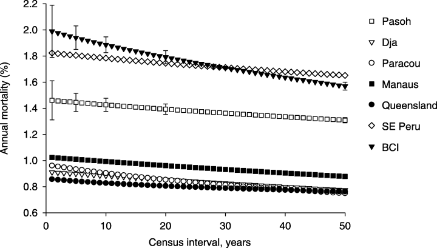

**Figure 1**

Calculated declines in stand mortality rate with increasing time between censuses in seven heterogeneous forests, using individual species as subpopulations, with 95% CIs given for BCI and Pasoh, for intervals of 1, 5, 10, 20 and 50 years.

Table 3. Intercepts and coefficients, with 95% CIs, fitted to simulated declines in mortality rates with increasing census interval length using species mortality rates as subpopulations. Bold denotes the coefficient that gives the best fit

|  | Linear Intercept | Linear Exponent | Linear *r* <sup>2</sup> | Exponential Intercept | Exponential Exponent | Exponential *r* <sup>2</sup> | Power Intercept | Power Exponent | Power *r* <sup>2</sup> |
| --- | --- | --- | --- | --- | --- | --- | --- | --- | --- |
| BCI | 1.971 ± 0.006 | −0.0084 ± 0.0002 | 0.992 | **1.981 ± 0.004** | **−0.0048 ± 0.0000** | **0.997** | 2.150 ± 0.050 | −0.0685 ± 0.0078 | 0.855 |
| Queensland | 0.847 ± 0.003 | −0.0018 ± 0.0000 | 0.971 | **0.848 ± 0.003** | **−0.0023 ± 0.0002** | **0.975** | 0.888 ± 0.008 | −0.0350 ± 0.0029 | 0.916 |
| Manaus | 1.023 ± 0.001 | −0.0030 ± 0.0000 | 0.998 | **1.025 ± 0.001** | **−0.0031 ± 0.0000** | **0.999** | 1.082 ± 0.018 | −0.0451 ± 0.0055 | 0.835 |
| Paracou | 0.946 ± 0.005 | −0.0042 ± 0.0002 | 0.983 | **0.952 ± 0.004** | **−0.0050 ± 0.0002** | **0.990** | 1.034 ± 0.024 | −0.0730 ± 0.0074 | 0.876 |
| SE Peru | 1.819 ± 0.002 | −0.0035 ± 0.0000 | 0.995 | **1.820 ± 0.002** | **−0.0020 ± 0.0000** | **0.997** | 1.890 ± 0.020 | −0.0297 ± 0.0033 | 0.858 |
| Dja | 0.911 ± 0.001 | −0.0028 ± 0.0000 | 0.999 | **0.913 ± 0.001** | **−0.0033 ± 0.0000** | **0.999** | 0.966 ± 0.018 | −0.0473 ± 0.0061 | 0.823 |
| Pasoh | 1.458 ± 0.002 | −0.0031 ± 0.0000 | 0.996 | **1.459 ± 0.001** | **−0.0022 ± 0.0000** | **0.998** | 1.520 ± 0.018 | −0.0328 ± 0.0038 | 0.852 |
| Mean | 1.282 | −0.0038 | 0.991 | 1.285 | −0.0032 | 0.994 | 1.362 | −0.0473 | 0.859 |
| 95% CI | 0.345 | 0.0016 | 0.008 | 0.346 | 0.0009 | 0.006 | 0.369 | 0.0128 | 0.022 |

Differences in the rate of change in λ with census interval among sites was not explained by differences in the number or proportion of species sampled at different sites and included as subpopulations: the results are similar whether sampling is standardized by using the same number (58) or the same proportion (12.8%) of the commonest species in all sites (mean rate of change, −0.0027 ± 0.001% a<sup>−1</sup> and −0.0026 ± 0.0005% a<sup>−1</sup>, respectively). Likewise, differences in the rate of change in mortality rate with census interval at each site were not correlated with the stand mortality rate of the site.

The small sample sizes (≥ 20 stems) used to calculate species’ mortality rates might have inflated variation in mortality rates among species leading to high rates of decline in mortality with increasing census interval length. We repeated the simulations for the Pasoh, BCI and North Queensland sites, which included a total of ≥ 50 species irrespective of whether we included only species with ≥ 20 stems, ≥ 40 stems or ≥ 80 stems. Both Pasoh and North Queensland showed little change in the rates of decline in mortality rates (Pasoh, declines −0.0022, −0.0021 and −0.0020, and North Queensland −0.0022, −0.0022 and −0.0019% a<sup>−1</sup>, including only species with ≥ 20, ≥ 40 or ≥ 80 stems, respectively). In contrast, BCI showed a marked decrease, from −0.0048% a<sup>−1</sup> using ≥ 20 stems as the threshold, to −0.0041 and −0.0036% a<sup>−1</sup> using ≥ 40 or ≥ 80 stems, respectively.

These simulations suggest that a forest stand with a 2.00% mortality rate measured over a 1-year interval would, on average, have a mortality rate of 1.88% over a 20-year interval, and 1.70% over a 50-year census interval, using the mean decline rate from the exponential fit. Using the greatest decline from one of the simulations (−0.005) the same forest stand would record a mortality rate of 1.56% with a 50-year census interval.

### long-term data sets

The average length of census interval within a plot is 4.0 ± 1.0 years (± 95% CI, range 1.4–8.9 years), while, on average, the longest census interval is nine times as long as the shortest (range 5–14 times). Eleven of the 14 long-term multicensus data sets showed declines in mortality rates with increasing census intervals, whether fitting linear, exponential or power functions (Fig. 2, Table 4). Of these 11 plots five showed significant declines. In contrast to theoretical predictions three plots showed increases in mortality rates with increasing census intervals, and two of these were significant (Table 4). The power function provided the best fit for 10 plots, with the linear and exponential fits both providing the best fit for two plots each (Fig. 2, Table 4).

Table 4. Intercepts and coefficients, with 95% CIs, fitted to declines in mortality rates with increasing census interval length from multicensus long-term plot data. Bold denotes the coefficient that gives the best fit

|  | Linear Intercept | Linear Exponent | Linear *r* <sup>2</sup> | Exponential Intercept | Exponential Exponent | Exponential *r* <sup>2</sup> | Power Intercept | Power Exponent | Power *r* <sup>2</sup> |
| --- | --- | --- | --- | --- | --- | --- | --- | --- | --- |
| Mt Lewis | 0.858 ± 0.088 | −0.0105 ± 0.0056 | 0.641 | **0.875 ± 0.095** | **−0.0154 ± 0.0081** | **0.670** | 0.980 ± 0.174 | −0.1319 ± 0.0756 | 0.624 |
| Mt Haig | 0.888 ± 0.101 | −0.0153 ± 0.0065 | 0.740 | 0.939 ± 0.105 | −0.0251 ± 0.0085 | 0.801 | **1.193 ± 0.130** | **−0.2408 ± 0.0475** | **0.919** |
| Bionte | **0.972 ± 0.120** | **−0.0072 ± 0.0149** | **0.158** | 0.974 ± 0.125 | −0.0079 ± 0.0163 | 0.156 | 1.001 ± 0.210 | −0.0457 ± 0.1086 | 0.126 |
| Kade Bekwai | 1.818 ± 0.207 | −0.0091 ± 0.0113 | 0.465 | 1.827 ± 0.213 | −0.0056 ± 0.0067 | 0.479 | **1.978 ± 0.350** | **−0.0673 ± 0.0692** | **0.548** |
| Kade Nzima | 3.277 ± 0.924 | −0.0314 ± 0.0516 | 0.415 | 3.359 ± 0.981 | −0.0124 ± 0.0180 | 0.456 | **4.187 ± 1.202** | **−0.1659 ± 0.1177** | **0.769** |
| Devimane | 1.301 ± 0.266 | −0.0059 ± 0.0116 | 0.255 | 1.313 ± 0.280 | −0.0053 ± 0.0098 | 0.271 | **1.637 ± 0.551** | **−0.1162 ± 0.1190** | **0.531** |
| Katlekan | 1.703 ± 0.302 | −0.0034 ± 0.0131 | 0.080 | **1.705 ± 0.310** | **−0.0021 ± 0.0080** | **0.081** | 1.777 ± 0.665 | −0.0297 ± 0.1288 | 0.066 |
| Melamane | 1.569 ± 0.414 | −0.0162 ± 0.0180 | 0.516 | 1.646 ± 0.461 | −0.0145 ± 0.0139 | 0.572 | **2.546 ± 0.883** | **−0.2589 ± 0.1283** | **0.824** |
| Bukit Lagong | **1.121 ± 0.091** | **0.0060 ± 0.0044** | **0.642** | 1.226 ± 0.152 | 0.0048 ± 0.0061 | 0.632 | 1.003 ± 0.188 | 0.0746 ± 0.0668 | 0.553 |
| Sungei Menyala | 1.663 ± 0.226 | 0.0258 ± 0.0108 | 0.851 | 1.690 ± 0.585 | 0.0122 ± 0.0067 | 0.810 | **1.326 ± 0.297** | **0.1764 ± 0.0771** | **0.852** |
| Manu | 2.364 ± 0.448 | −0.0201 ± 0.0425 | 0.302 | 2.376 ± 0.459 | −0.0096 ± 0.0191 | 0.315 | **2.502 ± 0.495** | **−0.0720 ± 0.0972** | **0.498** |
| Tambopata | 1.518 ± 0.146 | −0.0017 ± 0.0108 | 0.030 | 1.518 ± 0.147 | −0.0011 ± 0.0072 | 0.032 | **1.591 ± 0.248** | **−0.0259 ± 0.0648** | **0.168** |
| Budongo | 1.522 ± 0.306 | −0.0095 ± 0.0092 | 0.676 | 1.557 ± 0.317 | −0.0081 ± 0.0079 | 0.715 | **2.174 ± 0.534** | **−0.1848 ± 0.0844** | **0.898** |
| Carbonara | 1.543 ± 0.173 | 0.0021 ± 0.0104 | 0.018 | 1.575 ± 0.175 | 0.0015 ± 0.0066 | 0.022 | **1.477 ± 0.302** | **0.0252 ± 0.0762** | **0.046** |
| Mean | 1.570 | −0.0069 | 0.414 | 1.613 | −0.0063 | 0.430 | 1.812 | −0.0759 | 0.530 |
| 95% CI | 0.333 | 0.0070 | 0.145 | 0.336 | 0.0049 | 0.149 | 0.451 | 0.0629 | 0.165 |

On average, the power function was a significantly better fit than the exponential or linear functions (e.g. paired *t*-test on variance explained by power compared with exponential function, *t* = 2.99, d.f. = 13, *P* = 0.01; two tailed test). Fitting a power function to each long-term plot data set showed that the mean rate of decline for the long-term data was −0.076 ± 0.06% a<sup>−1</sup>, significantly less than zero (*t* = 2.36, d.f. = 13, *P* = 0.017, one-tailed test; Table 4). The power function captures the greater decline in mortality rates over very short time periods, and a lesser decline over much longer intervals. Indeed, it appears that beyond *c*. 15 years the relationship may asymptote (2, 3). This suggests that there are some small but very high mortality subpopulations within forest stands, which are removed over a period of time, leaving stems which have a relatively uniform distribution of mortality rates.

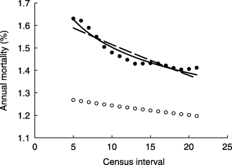

**Figure 3**

Difference in the shape of declines of stand mortality rate with increasing census interval length from simulated declines using species mortality rates as subpopulations (mean of seven sites, unfilled circles), and from long-term plot data (mean of 14 plots, filled circles). Both exponential (dashed line) and power (solid line) functions are fitted to the long-term plot data to show the difference in the quality of each fit.

Parameter estimates derived from curve-fitting partly depend upon the total length of time period used to fit the decline. As an initial test of whether the functional form that provided the best fit is dependent on the total monitoring period length we fitted linear, exponential and power functions to only the shortest half of all the census interval values available for each plot. The results were similar to those using the full data set for each site: for 10 plots a power function provided the best fit, and for four plots an exponential function provided the best fit (data not shown). The mean rate of decline using the power function was −0.094 ± 0.08% a<sup>−1</sup>, significantly less than zero, and indistinguishable from those obtained using much longer time series.

Visually comparing the simulation and long-term plot data suggests that on average the long-term plot data showed steeper declines over shorter intervals, and similar changes over intervals > 12 years, compared with the simulation data (Fig. 3). The plot data apparently show small increases (< 0.01%) in mortality rate between 13 and 15 years and 19–21 years, counter to theoretical predictions, most likely caused by combining the 14 different data sets, 11 declining and 3 increasing in mortality with increasing census interval, including our procedures of interpolation and extrapolation (see Methods). For the simulation data an exponential curve is a significantly better fit than a power function curve, but the opposite is true for the long-term data. However, when comparing the coefficients of either exponential or power function curve-fitting from the simulation and long-term data no significant differences emerge, because the long-term plots have such widely variable rates of decline.

The long-term data suggest that a forest stand with a 2.00% annual mortality rate measured over a 1-year interval would, on average, have a mortality rate of 1.59% over a 20-year interval, and 1.49% over a 50-year census interval, using the mean rate of decline from fitting a power function (−0.076). Taking the upper 95% CI exponent a forest with a 2.00% annual mortality rate measured over a 1-year interval would, on average, have a mortality rate of 1.32% with a 20-year interval decreasing to 1.16% over 50 years. Taking the lower 95% CI, the values would be 1.92% and 1.90%, respectively.

where λ is the mortality (or recruitment or turnover) rate, and *t* is the census interval length. This procedure moves rates to a census interval length of 1 year, which we call ‘census-corrected’. The 95% CI, also to one significant figure, is 0.06.

### re-analysis of published turnover rate sytheses

Annual turnover rates were correlated with the mid-year of the whole monitoring period for 65 sites from across the tropics, whether using Phillips's (1996) original data (*r*<sup>2</sup> = 0.20, *P* = 0.0002; Fig. 4a), census-corrected data, using equation 3 (*r*<sup>2</sup> = 0.14, *P* = 0.002; Fig. 4b), or census-corrected data using the upper 95% CI of the exponential decline in equation 3 (*r*<sup>2</sup> = 0.10, *P* = 0.01). For differences in census interval alone to explain the apparent increase in turnover rate over the late 20th century requires a decline in turnover with census interval length beyond the upper 99% CI of the decline in equation 3. Using site-specific correction factors for each plot with three or more censuses and fitting the best fit of either the linear, exponential or power function to each plot to census-correct the data does not alter the results either (*r*<sup>2</sup> = 0.13, *P* = 0.004).

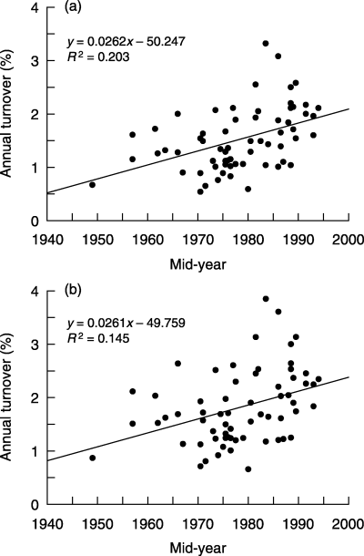

**Figure 4**

Annual turnover rate plotted against mid-year of the whole monitoring period for 65 forest sites from across the tropics. Top graph uses Phillips’ (1996) original published data, and below is the same data corrected for census interval using equation 3. Both regressions are significant (*P <* 0.01).

In addition to this pattern of change over the whole monitoring period, Phillips (1996) also showed that turnover rates increased in 23 of 27 sites with two or more measurements in each site, increasing by 3.9 ± 1.7% a<sup>−1</sup>. While the second census interval was significantly shorter than the first (by 1.3 ± 1.2 years, *t* = 2.25, d.f. = 26, *P* = 0.03; two-tailed test), reanalysis using census-corrected turnover rates does not substantially change the results: turnover still increases in 23 of 27 sites, by 3.7 ± 1.7% a<sup>−1</sup>. If the data are census-corrected using the upper 95% CI of the decline in equation 3 the rate of increase is still similar, at 3.6 ± 1.7% a<sup>−1</sup>. Using site-specific correction factors for the 27 sites did not change the results (3.9 ± 1.7% a<sup>−1</sup>). The figures using site-specific corrections are little different from the uncorrected figures as the plots with few censuses and short overall monitoring times have very widely varying behaviour, some showing very large *increases* in mortality with census interval (caused by stochastic events affecting small populations over short time periods), thus there is little overall effect of the correction.

If Phillips’ 65 sites are split into New and Old World sites, New World sites have significantly higher turnover than Old World sites (1.64 ± 0.17% a<sup>−1</sup>, *n* = 40 vs. 1.31 ± 0.23% a<sup>−1</sup>, *n* = 25; *t* = 2.25, d.f. = 64, *P* = 0.03). However, the Old World sites have census intervals over twice as long as the New World sites (20 ± 4.3 years vs. 8.8 ± 1.4 years). When we census-corrected turnover rates for New and Old world sites, average turnover rates were not significantly different (1.92 ± 0.21 vs. 1.63 ± 0.27% a<sup>−1</sup>; *t* = 1.70, d.f. = 64, *P* = NS). The non-significant difference narrows if we use the upper 95% CI for the decline in equation 3 (2.19 ± 0.25 vs. 1.94 ± 0.32% a<sup>−1</sup>; *t* = 1.70, d.f. = 64, *P* = NS).

The Old World sites reported by Phillips (1996) were also, on average, measured over a decade earlier in the 20th century than the New World sites (mean of 1971 vs. 1982). Simply adjusting the turnover value for each site to the average mid-year of the data set (1978) using the equation in Fig. 4(b) (‘time-corrected’ data) suggests that the turnover rates of the New and Old World sites are very similar: 1.54 ± 0.16% and 1.47 ± 0.22% a<sup>−1</sup>, respectively. When turnover values are corrected for *both* census-interval differences *and* when a study took place, this gives mean turnover rates for both New and Old World sites that are almost identical: 1.81 ± 0.19% and 1.80 ± 0.15% a<sup>−1</sup>, respectively. The mean census-corrected and time-adjusted (to 1978) turnover rate for the 65 plots from across the tropics is 1.81 ± 0.16% a<sup>−1</sup>.

## Discussion

### declines in mortality rates over time

We have shown that stand-level mortality rates decline with increasing census interval length, as predicted from theory, whether rates are simulated using the mortality rates of many species in a stand as subpopulations, or derived from monitoring cohorts of trees in long-term multicensus plots (1, 2, 3, Tables 3 and 4). Although declines are modest on an annual basis, correcting for census interval differences using our empirically derived equation 3 may result in the re-appraisal of differences in dynamics between different forests. For example, two sites from Phillips’ (1996) analysis, Caño Rosalba (CR1), Venezuela, and Kade (K1), Ghana, both have reported annual turnover rates of 1.49%, but these are obtained from census intervals of 2 and 25 years, respectively. Census-corrected turnover rates suggest that Kade has higher annual turnover than Caño Rosalba (1.93% vs. 1.57%). More recently published studies further highlight how differing census interval lengths can impact on intersite comparisons: the annual mortality rate for Budongo, Uganda, between 1939 and 1993 is 1.05% (Sheil *et al*. 2000), while the reported rate at Pasoh, Malaysia, between 1987 and 1990 is 1.16% (Condit *et al*. 1999), 10% higher than Budongo. When the results are census-corrected Budongo has a higher mortality rate (1.42%) than Pasoh (1.26%).

The long-term plot data, while showing average declines in mortality rate with increasing census interval, are extremely variable. Of the 14 plots studied, 11 showed decreases, five of which were significant, while three, counter to our theoretical predictions, showed increases, of which two were significant (Sungei Menyala, Bukit Lagong). We suggest that these increases may be caused by long-term non-linear temporal changes in mortality and recruitment rates. Our methods of accounting for potential increases in mortality rates over the late 20th century assume that any change, if present, is linear. This may not be the case, and some non-linear changes in forest dynamics may cause *increases* in mortality rates with increasing census intervals, as calculated using the methods described in this paper. For example, if the recruits to a plot have differing mortality rates, and mortality distribution, compared with the stems that died, and these temporal changes are systematic and non-linear, then this would affect the changes in mortality rates we detect with lengthening census intervals, including scenarios where an increase in mortality rate with lengthening census intervals is discoverable. However, the precise cause(s) of these increases in mortality rates with increasing census interval requires further research.

A power function provides the best fit for 10 of the 14 long-term plots, and on average this was a best fit across the 14 plots. However, as discussed, the data are highly variable. This may be caused by inherent stochastic variation, or measurement errors, or may reflect different functional forms of decline in different forests. We do not know whether the distribution of mortality rates of stems in different forests are similar or quite different, thus at present it is unknown whether our empirical approach either identifies the correct functional form, or, indeed, that a single functional form is applicable to all forests. We firstly used a generic correction factor derived from the mean decline from all 14 long-term plots to correct other data. This is better than ignoring the census interval problem, but if different forests have different functional forms of decline, then a site-specific correction may be more appropriate. However, site-specific corrections will often be based on very few data points from a single site, or from a single small plot, and thus will include large stochastic variation leading to a poor estimate of the rate of decline for a single site. Some of the site-specific estimates from plots with only two intervals actually show very large *increases* in mortality with increasing census interval, for which there is no obvious cause, and this is likely to be merely variability in the system. For these reasons, we suggest that corrections may be done on both a generic, and where possible, site-specific basis. Nevertheless, we recommend a generic correction at this stage, as (i) the variation in mortality rates over short time periods and small sample sizes is known to be very large, and (ii) the simulation data suggest that different forests may have similar functional forms of decline.

The most striking result is that the long-term forest plot data show a much steeper rate of decline in mortality over shorter census intervals than the simulations using species as subpopulations (Fig. 3). The steepness of the decline in mortality rate with increasing census interval is governed by the distribution of mortality rates of all stems, with notably steep declines associated with a fraction of the population having much higher mortality rates than the rest (Sheil & May 1996). This suggests that trees in the cohorts measured in the long-term plots contained subpopulations with very high mortality rates, which once dead left trees with a relatively narrow distribution of mortality rates (hence the flattening of the curve in Fig. 3 beyond *c*. 15 years). These very high mortality subpopulations were not captured by the species mortality rates we included in equation 2. Three possible explanations for this are examined below. (i) The simulations sampled only commoner species and thereby may have under-represented rarer species, some of which may have very dynamic populations. (ii) The assumptions that mortality rates were equal for all individuals within a species and that the mortality rate of a given stem was constant and independent of other stems may be incorrect. (iii) There may have been temporal fluctuations in mortality.

The simplest explanation of why the large-scale data sets did not include all the variation in mortality rates is that by including only species with ≥ 20 stems, we only included commoner species. These stems represent 35 ± 13% of all species at a site (range 13–58%), and 77 ± 13% of all stems at a site (range 44–97%). Conceivably, rarer species will show wider variation in mortality rates than commoner species; for example, very ‘early successional’ species, which often have high mortality rates, tend to occur at low densities in old-growth forests (Swaine 1994; Condit *et al*. 1995). Although comparing simulated declines with only very common species (≥ 80 stems), rather than species with ≥ 20 stems, did not show large differences at Pasoh and North Queensland, there was a large difference at BCI. This may be because BCI is known to have a large and relatively common pioneer community that is largely absent at Pasoh and in North Queensland (Condit *et al*. 1999). Thus the simulations may have under-represented the distribution of mortality rates within a stand.

All individuals within a species were assumed to have the same probability of dying, but any within-species differences could further increase heterogeneity. Examples include possible differences in mortality rate by size class, and differing mortality rates when stems of the same species occupy different microhabitats. Differences in the mortality rate of a given species by size class have been documented at several sites, thus these mechanisms could plausibly widen the distribution of mortality rates within a forest stand (Mervart 1972; Hubbell & Foster 1990; Vanclay 1991; Clark & Clark 1992).

The results from the simulations are constrained by the assumptions in equation 2, primarily that the probability of mortality of a given stem is constant and independent of its neighbours (Sheil & May 1996). Obvious violations of these assumptions include local competition for limiting resources, and the impact of other stems dying nearby. With local competition two identical individuals would have different probabilities of dying depending on the competitive interactions with their respective neighbours. This may explain why slow growing individuals have higher mortality rates than faster growing equivalent-sized individuals (Swaine *et al*. 1987a,b). Mortality events do impact on nearby trees, for example, increasing mortality through damage to the remaining trees or decreasing mortality through increasing levels of essential resources, such as light following canopy opening (Lewis 1998). The much steeper declines in mortality in the long-term plot data suggest these types of effects may be important processes in real populations.

Finally, the simulations do not include possible changes in the distribution of mortality rates over time. This is likely, because the environmental noise that affects processes that in turn affect tree mortality rates (e.g. droughts, Condit *et al*. 1995, wind events, Nelson *et al*. 1994, or diseases) may become more variable as the study period is extended. This is because environmental noise is not random (‘white noise’), but is characterized by strong correlations on many scales (‘pink noise’; Halley 1996; Gisiger 2001). The longer plots are monitored, the more likely it is that environmental conditions will be such that the mortality rates of some subpopulations will be temporarily increased, so leading to a longer ‘tail’ in the mortality rate distribution and increasing the steepness of decline in mortality with increasing census interval. The potential impact of temporal changes in mortality-rate distributions is considerable; for example, the Pasoh 50-ha plot showed highly significant differences in mortality rate between 1987 and 1990 (1.16%), and between 1990 and 1995 (1.60%) (Condit *et al*. 1999). Due to the large size of the Pasoh plot, these differences are very unlikely to be explained by very local mosaic/successional effects, which suggests that differing environmental conditions caused the differing stand mortality rates, and hence the distributions of mortality rates of the component subpopulations changed over time.

### reanalysis of previous results

The conclusion that turnover rates have increased in tropical forests over the late 20th century is robust to the charge that this is an artefact due to the combination of data that vary in census interval (cf. Sheil 1995). Two tests using Phillips's (1996) expanded turnover data set show that the census interval effect does not affect Phillips’ conclusions about turnover increasing over time, whether using the generic census correction in equation 3 or site-specific corrections, where applicable (Fig. 4). To account for the increase in turnover, the declines in turnover with increasing census interval would have to be beyond the upper 99% CI of the decline parameter reported here, which is very unlikely.

Sheil's (1995) original critique of the evidence for increasing turnover over the late 20th century also suggests that the apparent increase could be explained by a single event, the 1982–83 El Niño Southern Oscillation (ENSO), as many of the recent data spanned this event. However, the rigorous assessment of the hypothesis that the apparent increase in turnover rates is due to a short-term response to an extreme synchronized global event, such as the 1982–83 ENSO, or more generally to a possible late 20th century increase in the frequency and intensity of ENSO events, is beyond the scope of this paper. Quantifying to what extent a forest is ‘ENSO-affected’ and quantifying whether ENSO events are more intense and frequent later in the 20th century, and then understanding whether individual ENSO events are driving local and global changes in turnover values, remains a challenge for ecologists (Lewis *et al*. 2004b; Malhi & Wright 2004). However, recent analyses from Amazonia have shown that growth, recruitment and mortality rates have simultaneously increased within the same plots over the 1980s and 1990s, as has net above-ground biomass, both in areas largely unaffected, and in those strongly affected, by ENSO events (Baker *et al*. 2004; Lewis *et al*. 2004a; Phillips *et al*. 2004). Factors that potentially explain such widespread and simultaneous changes should be the subject of detailed investigations.

If turnover rates have been increasing over time, as current evidence suggests, then it becomes important to know *when* the plots to be compared were measured. Comparing data from, say, the 1960s with data from the 1990s may lead to erroneous conclusions. Indeed, if forest dynamics have been accelerating over recent decades then standardizing for the year of monitoring will need to become standard practice. More generally, as evidence accumulates that ecosystems are responding to global change, particularly to increases in atmospheric carbon dioxide concentrations, nitrogen inputs, temperature increases and changes in rainfall patterns, much ecological data may become difficult to interpret without considering *when* studies took place.

The Old World forest plots compiled by Phillips (1996) were censused much earlier in the last century than the New World plots, with mean mid-years of 1971 and 1982, respectively. Adjusting turnover rates from the New and Old World plots to a common census interval length, using equation 3, and a common mid-year of monitoring gives almost identical turnover rates for the New and Old World tropics (1.81 vs. 1.80% a<sup>−1</sup>). This result seems sensible, as there is no *a priori* reason why many plots from many soil types and climates from one continent should have higher turnover rates than many plots from many soil types and climates from three other continents combined. The current best estimate of the pan-tropical average annual turnover rate for tropical forests is therefore 1.81% (mode = 2.06, median = 1.78, SD = 0.64, min = 0.60, max = 3.71), for an average census mid-year of 1978 and a census interval length of one (using equation 3). Forests can therefore be defined as less or more dynamic based on the number of standard deviations standardized plot turnover data are from the mean, or in relation to the median or mode, due to the strong right skew (0.69) and lesser leptokurtosis (0.39) of the distribution.

### recommendations

Mortality, recruitment and turnover rates decline with increasing census interval, as previously shown theoretically, and now demonstrated empirically. This effect should be taken into account. In addition, stand dynamic rates are highly variable over short time-scales and small spatial scales. The frequency of measurement and plot size needed for any field study will clearly depend upon the questions being asked and resources available. For example, the most accurate stand level rates for comparisons with other plots will always come from monitoring many trees for many years, while trends over time are probably most accurately elucidated by annual measurements. However, common protocols are required for comparative studies. Currently, probably the most common census interval length is the 5-year interval, which is becoming a *de facto* standard (seemingly due to resource constraints). In order to maximize intercensus and intersite comparability we therefore recommend collecting and reporting results in intervals as near to 5 years as possible, as well as reporting results for each interval and for the longest period possible. This combination of results reduces census interval problems, and provides the most accurate results. If adequate data are available, then the calculation of a site-specific correction factor using the methods described in this paper may be appropriate. For comparisons where census intervals do unavoidably vary, and robust local corrections are unavailable, then standardization to account for the census interval artefact, using equation 3, will be necessary.

## Acknowledgements

This work on permanent sample plot methodologies and analyses is funded by the UK Natural Environment Research Council (NER/A/S/2000/00532 and GR9/04635) and the EU Fifth Framework programme (CARBONSINK-LBA). Y. Malhi is funded by the Royal Society. We thank E. Losos and R. Condit for helping to access the CTFS data sets, and M. Swaine and the University of Ghana Botany Department for providing unpublished data (Kade). Mortality data analysed for the first time here were collected with the support of the following: J. Froment, J. Vautherin, P. Seme, J. Rossel of ECOFAC, and the 6th FED EU project (Dja Faunal Reserve site); Brazil's National Institute for Amazonian Research (INPA), MCT, the European Union and Department for International Development (UK), and CNPq, Brazil (BIONTE site); NASA-LBA, Andrew W. Mellon Foundation, US Agency for International Development, Smithsonian Institute (Biological Dynamics of Forest Fragments Project site); the late A.H. Gentry, F. Angulo, C. Díaz, J. Janovec, N. Jaramillo, K. Johnson, S. Rose, M. Stern, M. Sánchez, INRENA, Cuzco Amazónico, Peruvian Safaris S.A., UNSAAC, American Philosophical Society, NGS (5472–95), National Science Foundation, WWF-US/Garden Club of America, Conservation International, MacArthur and Mellon Foundations, National University of San Antonio de Abad de Cusco, and a NERC Research Fellowship to OP (SE Peru site); Forest Research Institute of Malaysia, US National Science Foundation, Smithsonian Tropical Research Institute (Pasoh site); Professor J. P. Veillon and colleagues of the Instituto de Silvicultura, Universidad de Los Andes, Merida, Venezuela, USDA International Institute of Tropical Forestry and the University of Illinois (Agreement no. 19-91-064) (Carbonara); Uganda Forest Department, ODA (now DFID) Forestry Research Programme (R4737), Makerere University Herbarium, Budongo Forest Project team, Kew Herbarium, Tony Katende, Olivia Maganyi, Andy Plumptre, Chris Bakuneeta, Abel Musinguzi, Silvano Muringeera, Rufino Tolit, Tim Synnott, Peter Savill, Quentin Cronk, Jo Eggeling, Colyear Dawkins and Howard Wright (Budongo); Dr Geoff Stocker and colleagues at CSIRO (Mt Lewis, Mt Haig). We also thank Jerome Chave and an anonymous referee for valuable comments on the manuscript.

December 2004

Pages 929-944